# Support Vector Machines

```python
#Import library
import pandas as pd
import numpy as np
import matplotlib.pyplot as plt
import seaborn as sns
%matplotlib inline

from sklearn.svm import SVC
from scipy.sparse import csc_matrix
from scipy.sparse.linalg import svds
```

### Read the input file 'Diabetes.csv' using Pandas and check it's column names(1 Marks)

```python
diabetes=pd.read_csv('diabetes.csv')
diabetes.head()
```

|  | Pregnancies | Glucose | BloodPressure | SkinThickness | Insulin | BMI | DiabetesPedigreeFunction | Age | Outcome |
| --- | --- | --- | --- | --- | --- | --- | --- | --- | --- |
| 0 | 6 | 148 | 72 | 35 | 0 | 33.6 | 0.627 | 50 | 1 |
| 1 | 1 | 85 | 66 | 29 | 0 | 26.6 | 0.351 | 31 | 0 |
| 2 | 8 | 183 | 64 | 0 | 0 | 23.3 | 0.672 | 32 | 1 |
| 3 | 1 | 89 | 66 | 23 | 94 | 28.1 | 0.167 | 21 | 0 |
| 4 | 0 | 137 | 40 | 35 | 168 | 43.1 | 2.288 | 33 | 1 |

```python
# Eye ball the imported dataset
```

### Check dimension of dataset

```python
diabetes.shape
```

```
(768, 9)
```

```python
print(diabetes.groupby('Outcome').size())
```

```
Outcome
0    500
1    268
dtype: int64
```

```python
diabetes.isnull().sum()
diabetes.isna().sum()
```

```
Pregnancies                 0
Glucose                     0
BloodPressure               0
SkinThickness               0
Insulin                     0
BMI                         0
DiabetesPedigreeFunction    0
Age                         0
Outcome                     0
dtype: int64
```

```
Pregnancies                 0
Glucose                     0
BloodPressure               0
SkinThickness               0
Insulin                     0
BMI                         0
DiabetesPedigreeFunction    0
Age                         0
Outcome                     0
dtype: int64
```

### Check distribution of dependent variable, Outcome and plot it (1 Marks)

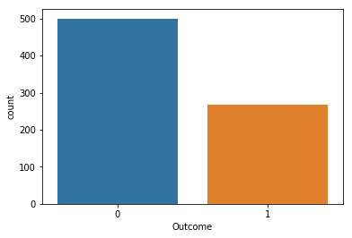

```python
sns.countplot(diabetes['Outcome'],label="Count")
```

#### Blood pressure : By observing the data we can see that there are 0 values for blood pressure. And it is evident that the readings of the data set seems wrong because a living person cannot have diastolic blood pressure of zero. By observing the data we can see 35 counts where the value is 0.

```python
print("Total : ", diabetes[diabetes.BloodPressure == 0].shape[0])

print(diabetes[diabetes.BloodPressure == 0].groupby('Outcome')['Age'].count())
```

```
Total :  35
Outcome
0    19
1    16
Name: Age, dtype: int64
```

#### Plasma glucose levels : Even after fasting glucose level would not be as low as zero. Therefor zero is an invalid reading. By observing the data we can see 5 counts where the value is 0.

```python
print("Total : ", diabetes[diabetes.Glucose == 0].shape[0])

print(diabetes[diabetes.Glucose == 0].groupby('Outcome')['Age'].count())
```

```
Total :  5
Outcome
0    3
1    2
Name: Age, dtype: int64
```

#### Skin Fold Thickness : For normal people skin fold thickness can’t be less than 10 mm better yet zero. Total count where value is 0 : 227.

```python
print("Total : ", diabetes[diabetes.SkinThickness == 0].shape[0])

print(diabetes[diabetes.SkinThickness == 0].groupby('Outcome')['Age'].count())
```

```
Total :  227
Outcome
0    139
1     88
Name: Age, dtype: int64
```

#### BMI : Should not be 0 or close to zero unless the person is really underweight which could be life threatening.

```python
print("Total : ", diabetes[diabetes.BMI == 0].shape[0])

print(diabetes[diabetes.BMI == 0].groupby('Outcome')['Age'].count())
```

```
Total :  11
Outcome
0    9
1    2
Name: Age, dtype: int64
```

#### Insulin : In a rare situation a person can have zero insulin but by observing the data, we can find that there is a total of 374 counts.

```python
print("Total : ", diabetes[diabetes.Insulin == 0].shape[0])

print(diabetes[diabetes.Insulin == 0].groupby('Outcome')['Age'].count())
```

```
Total :  374
Outcome
0    236
1    138
Name: Age, dtype: int64
```

### Out of 768 data points, 500 are labeled as 0 and 268 as 1.

### Outcome 0 means No diabetes, outcome 1 means diabetes

```python
diabetes.dtypes
```

```
Pregnancies                   int64
Glucose                       int64
BloodPressure                 int64
SkinThickness                 int64
Insulin                       int64
BMI                         float64
DiabetesPedigreeFunction    float64
Age                           int64
Outcome                       int64
dtype: object
```

```python
# Check data types and info of dataset
diabetes.info()
```

```
<class 'pandas.core.frame.DataFrame'>
RangeIndex: 768 entries, 0 to 767
Data columns (total 9 columns):
Pregnancies                 768 non-null int64
Glucose                     768 non-null int64
BloodPressure               768 non-null int64
SkinThickness               768 non-null int64
Insulin                     768 non-null int64
BMI                         768 non-null float64
DiabetesPedigreeFunction    768 non-null float64
Age                         768 non-null int64
Outcome                     768 non-null int64
dtypes: float64(2), int64(7)
memory usage: 54.1 KB
```

### Check data distribution using summary statistics and provide your findings(2 Marks)

```python
diabetes.describe()
```

|  | Pregnancies | Glucose | BloodPressure | SkinThickness | Insulin | BMI | DiabetesPedigreeFunction | Age | Outcome |
| --- | --- | --- | --- | --- | --- | --- | --- | --- | --- |
| count | 768.000000 | 768.000000 | 768.000000 | 768.000000 | 768.000000 | 768.000000 | 768.000000 | 768.000000 | 768.000000 |
| mean | 3.845052 | 120.894531 | 69.105469 | 20.536458 | 79.799479 | 31.992578 | 0.471876 | 33.240885 | 0.348958 |
| std | 3.369578 | 31.972618 | 19.355807 | 15.952218 | 115.244002 | 7.884160 | 0.331329 | 11.760232 | 0.476951 |
| min | 0.000000 | 0.000000 | 0.000000 | 0.000000 | 0.000000 | 0.000000 | 0.078000 | 21.000000 | 0.000000 |
| 25% | 1.000000 | 99.000000 | 62.000000 | 0.000000 | 0.000000 | 27.300000 | 0.243750 | 24.000000 | 0.000000 |
| 50% | 3.000000 | 117.000000 | 72.000000 | 23.000000 | 30.500000 | 32.000000 | 0.372500 | 29.000000 | 0.000000 |
| 75% | 6.000000 | 140.250000 | 80.000000 | 32.000000 | 127.250000 | 36.600000 | 0.626250 | 41.000000 | 1.000000 |
| max | 17.000000 | 199.000000 | 122.000000 | 99.000000 | 846.000000 | 67.100000 | 2.420000 | 81.000000 | 1.000000 |

### Do correlation analysis and bivariate viualization with Insights(1 Marks)

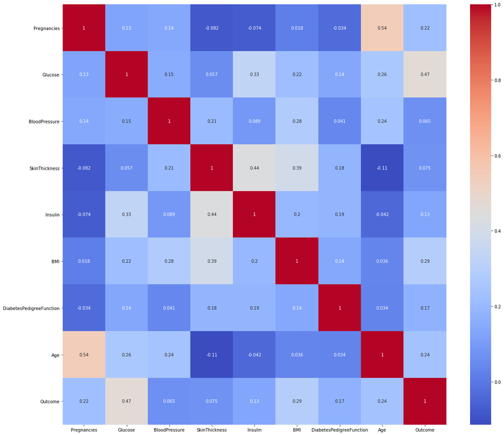

```python
corr = diabetes.corr()
fig = plt.figure(figsize = (20,18))
sns.heatmap(corr, annot = True, cmap = "coolwarm")
```

```python
corr.Outcome
```

```
Pregnancies                 0.221898
Glucose                     0.466581
BloodPressure               0.065068
SkinThickness               0.074752
Insulin                     0.130548
BMI                         0.292695
DiabetesPedigreeFunction    0.173844
Age                         0.238356
Outcome                     1.000000
Name: Outcome, dtype: float64
```

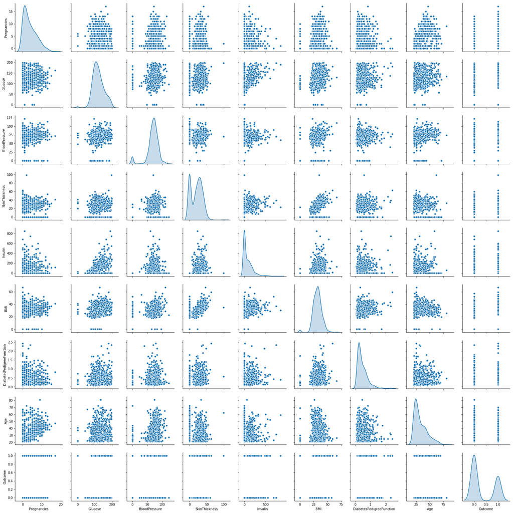

```python
# Bivariate
sns.pairplot(diabetes, diag_kind='kde')
```

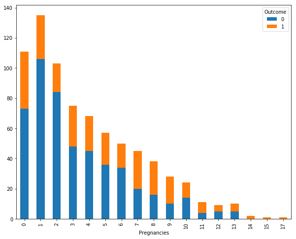

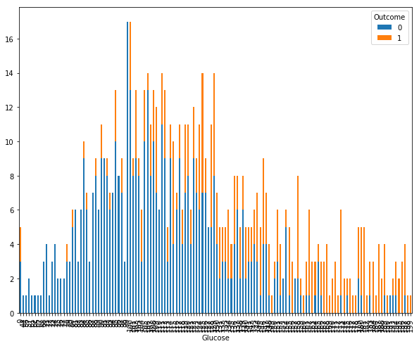

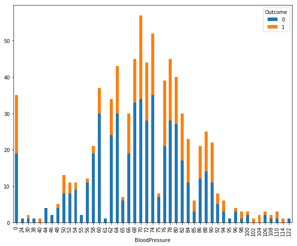

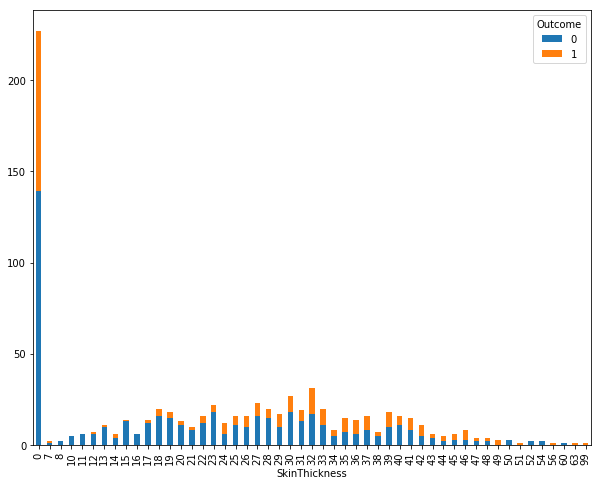

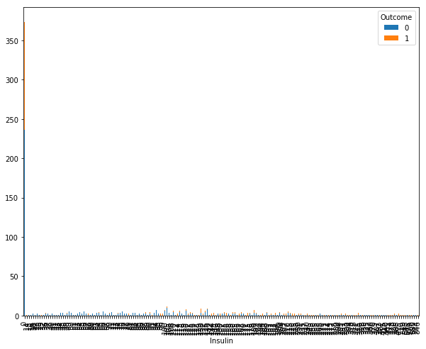

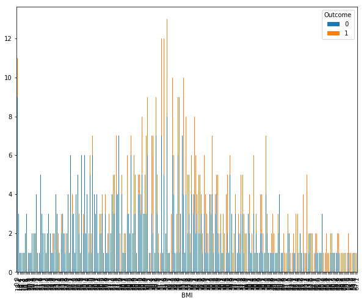

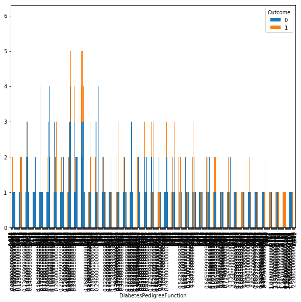

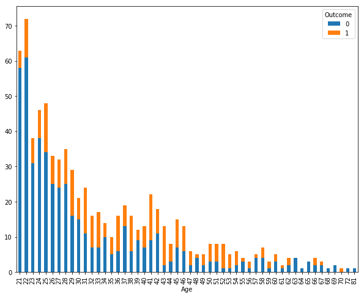

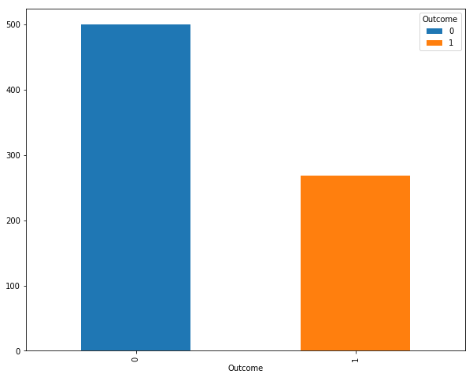

```python
# Bivariate: Plotting the graphs of all the features by linking it with dependent variable
for i in diabetes.columns:
    diabetes.groupby(i)['Outcome'].value_counts().unstack().plot(kind = 'bar', stacked = True, figsize = (10,8))
```

#### Do train and test split with stratify sampling on Outcome variable to maintain the distribution of dependent variable(1 Marks)

```python
feature_names = ['Pregnancies', 'Glucose', 'BloodPressure', 'SkinThickness', 'Insulin', 'BMI', 'DiabetesPedigreeFunction', 'Age']
X = diabetes[feature_names]
y = diabetes.Outcome
```

```python
models = []
models.append(('SVC', SVC()))
```

```python
from sklearn.model_selection import train_test_split
from sklearn.model_selection import cross_val_score
from sklearn.metrics import accuracy_score
```

```python
X_train, X_test, y_train, y_test = train_test_split(X, y, stratify = diabetes.Outcome, random_state=0)
```

### Train Support Vector Machine Model(1 Marks)

```python
# use from sklearn.svm import SVC
names = []
scores = []
for name, model in models:
    model.fit(X_train, y_train)
    y_pred = model.predict(X_test)
    scores.append(accuracy_score(y_test, y_pred))
    names.append(name)
tr_split = pd.DataFrame({'Name': names, 'Score': scores})
print(tr_split)
```

[output not shown]

```
  Name     Score
0  SVC  0.651042
```

```python
print ("Accuracy : ", accuracy_score(y_test,y_pred)*100,"%")
```

```
Accuracy :  65.10416666666666 %
```

```python
# your insights
```

### Scale the data points using MinMaxScaler ( 1 Marks)

```python
from sklearn.preprocessing import MinMaxScaler
scaler = MinMaxScaler()
```

### Fit SVM Model on Scale data and give your observation( 1 Marks)

```python
X_train_scaled = scaler.fit_transform(X_train)
X_test_scaled = scaler.fit_transform(X_test)
svc = SVC()
svc.fit(X_train_scaled, y_train)
print("Accuracy on training set: {:.2f}".format(svc.score(X_train_scaled, y_train)))
print("Accuracy on test set: {:.2f}".format(svc.score(X_test_scaled, y_test)))
```

```
SVC(C=1.0, cache_size=200, class_weight=None, coef0=0.0,
  decision_function_shape='ovr', degree=3, gamma='auto_deprecated',
  kernel='rbf', max_iter=-1, probability=False, random_state=None,
  shrinking=True, tol=0.001, verbose=False)
```

```
Accuracy on training set: 0.76
Accuracy on test set: 0.77
```

# we can try increasing either C or gamma to fit a more complex model.

### Try improving the model accuracy using C=1000 (1 Marks)

```python
svc = SVC(C=1000)
svc.fit(X_train_scaled, y_train)
print("Accuracy on training set: {:.3f}".format(
    svc.score(X_train_scaled, y_train)))
print("Accuracy on test set: {:.3f}".format(svc.score(X_test_scaled, y_test)))
```

```
SVC(C=1000, cache_size=200, class_weight=None, coef0=0.0,
  decision_function_shape='ovr', degree=3, gamma='auto_deprecated',
  kernel='rbf', max_iter=-1, probability=False, random_state=None,
  shrinking=True, tol=0.001, verbose=False)
```

```
Accuracy on training set: 0.785
Accuracy on test set: 0.802
```

### Let's try to explore different Kernel and C (Bonus for practice)

```python
import multiprocessing
from sklearn.model_selection import GridSearchCV
```

```python
 param_grid = [    {
     'kernel': ['linear', 'rbf', 'poly', 'sigmoid'],
     'C': [ 0.1, 0.2, 0.4, 0.5, 1.0, 1.5, 1.8, 2.0, 2.5, 3.0 ]    } ]
```

```python
gs = GridSearchCV(estimator=SVC(), param_grid=param_grid,scoring='accuracy', cv=10, n_jobs=multiprocessing.cpu_count())
```

```python
gs.fit(X_train_scaled, y_train)
```

```
GridSearchCV(cv=10, error_score='raise-deprecating',
       estimator=SVC(C=1.0, cache_size=200, class_weight=None, coef0=0.0,
  decision_function_shape='ovr', degree=3, gamma='auto_deprecated',
  kernel='rbf', max_iter=-1, probability=False, random_state=None,
  shrinking=True, tol=0.001, verbose=False),
       fit_params=None, iid='warn', n_jobs=4,
       param_grid=[{'kernel': ['linear', 'rbf', 'poly', 'sigmoid'], 'C': [0.1, 0.2, 0.4, 0.5, 1.0, 1.5, 1.8, 2.0, 2.5, 3.0]}],
       pre_dispatch='2*n_jobs', refit=True, return_train_score='warn',
       scoring='accuracy', verbose=0)
```

```python
gs.best_estimator_
```

```
SVC(C=1.0, cache_size=200, class_weight=None, coef0=0.0,
  decision_function_shape='ovr', degree=3, gamma='auto_deprecated',
  kernel='linear', max_iter=-1, probability=False, random_state=None,
  shrinking=True, tol=0.001, verbose=False)
```

```python
gs.best_score_
```

```
0.7690972222222222
```